# Problem Set 5

This assignment is the first part of problem set 5 of the Udacity course *Data Analysis with R* lesson 5: *Explore Many Variables*. This part of the problem set consists in a set of questions/tasks answered below.

### Diamonds

Load the diamonds dataset

```r
suppressMessages(library(ggplot2))
data(diamonds)
str(diamonds)
```

```
## 'data.frame':    53940 obs. of  10 variables:
##  $ carat  : num  0.23 0.21 0.23 0.29 0.31 0.24 0.24 0.26 0.22 0.23 ...
##  $ cut    : Ord.factor w/ 5 levels "Fair"<"Good"<..: 5 4 2 4 2 3 3 3 1 3 ...
##  $ color  : Ord.factor w/ 7 levels "D"<"E"<"F"<"G"<..: 2 2 2 6 7 7 6 5 2 5 ...
##  $ clarity: Ord.factor w/ 8 levels "I1"<"SI2"<"SI1"<..: 2 3 5 4 2 6 7 3 4 5 ...
##  $ depth  : num  61.5 59.8 56.9 62.4 63.3 62.8 62.3 61.9 65.1 59.4 ...
##  $ table  : num  55 61 65 58 58 57 57 55 61 61 ...
##  $ price  : int  326 326 327 334 335 336 336 337 337 338 ...
##  $ x      : num  3.95 3.89 4.05 4.2 4.34 3.94 3.95 4.07 3.87 4 ...
##  $ y      : num  3.98 3.84 4.07 4.23 4.35 3.96 3.98 4.11 3.78 4.05 ...
##  $ z      : num  2.43 2.31 2.31 2.63 2.75 2.48 2.47 2.53 2.49 2.39 ...
```

### Price Histograms with Facet and Color

Create a histogram of diamond prices. Facet the histogram by diamond color and use cut to color the histogram bars.

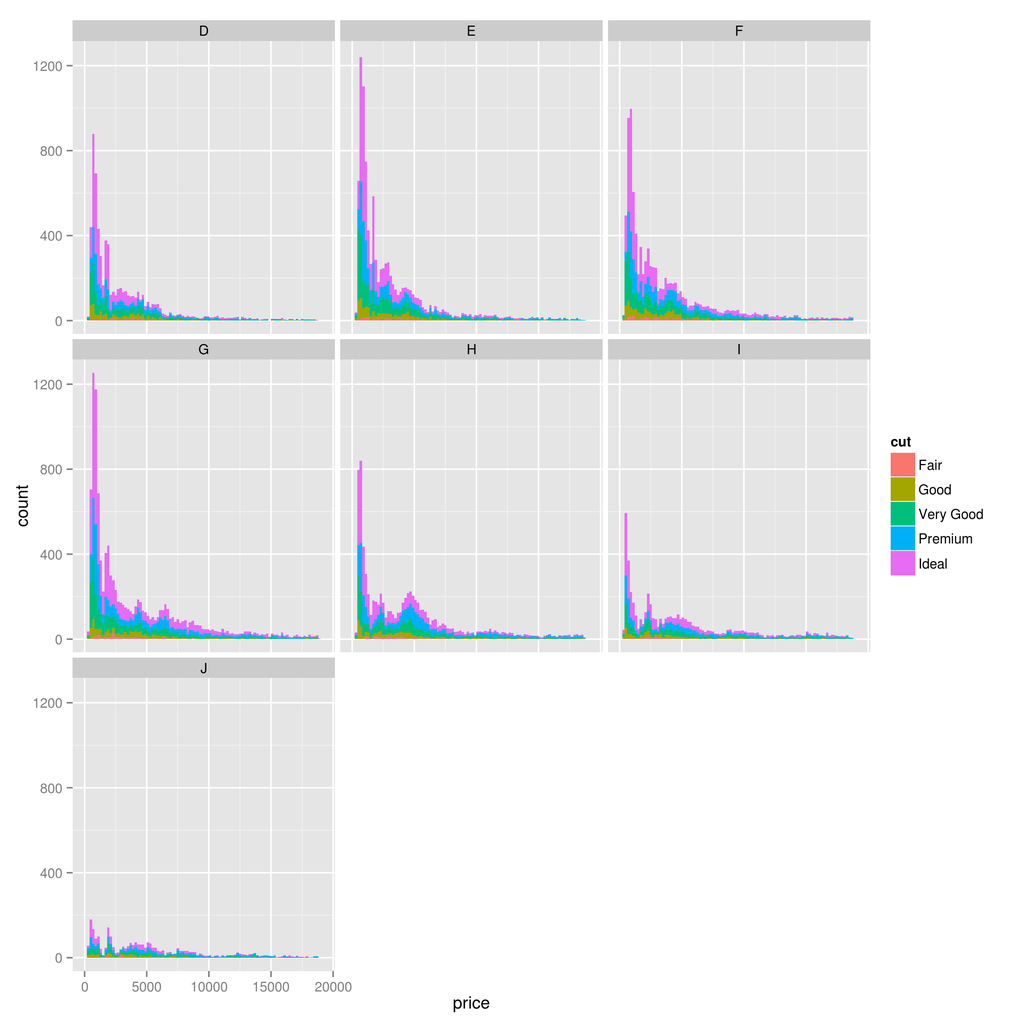

```r
ggplot(aes(x = price), data = diamonds) +
  geom_histogram(binwidth = 200, aes(fill = cut)) +
  facet_wrap(~color)
```

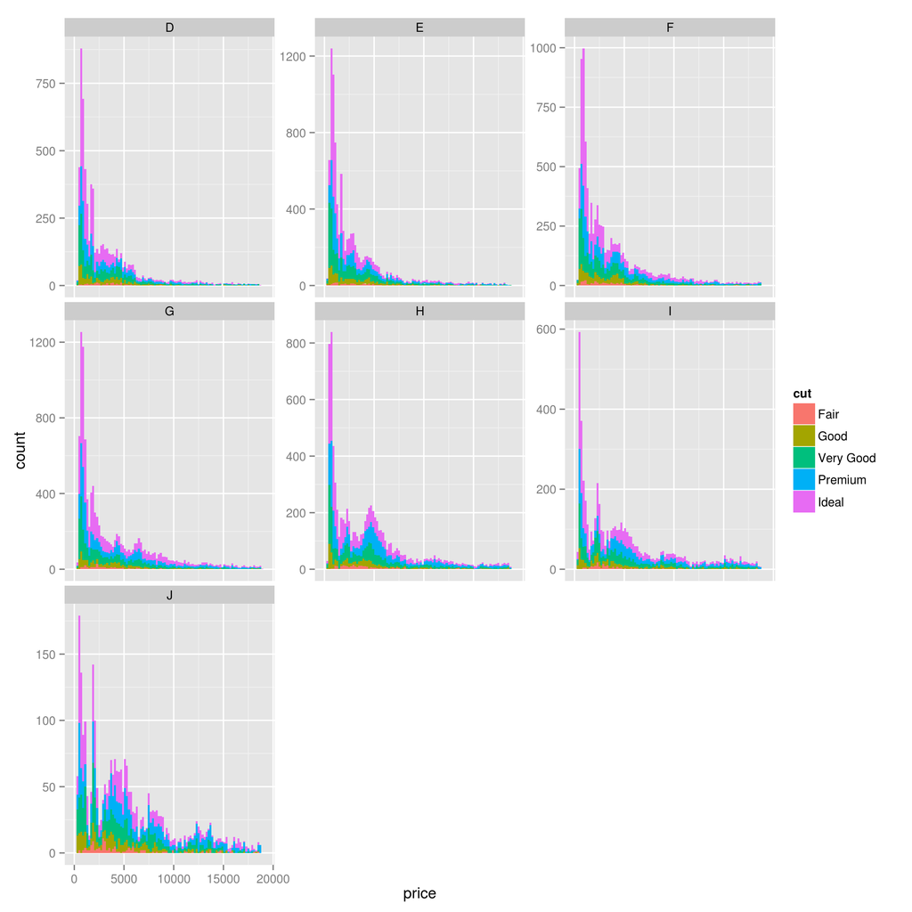

```r
## scales = free_y
ggplot(aes(x = price), data = diamonds) +
  geom_histogram(binwidth = 200, aes(fill = cut)) +
  facet_wrap(~color, scales = "free_y")
```

### Price vs. Table Colored by Cut

Create a scatterplot of diamond price vs. table (width of top of diamond relative to widest point) and color the points by the cut of the diamond.

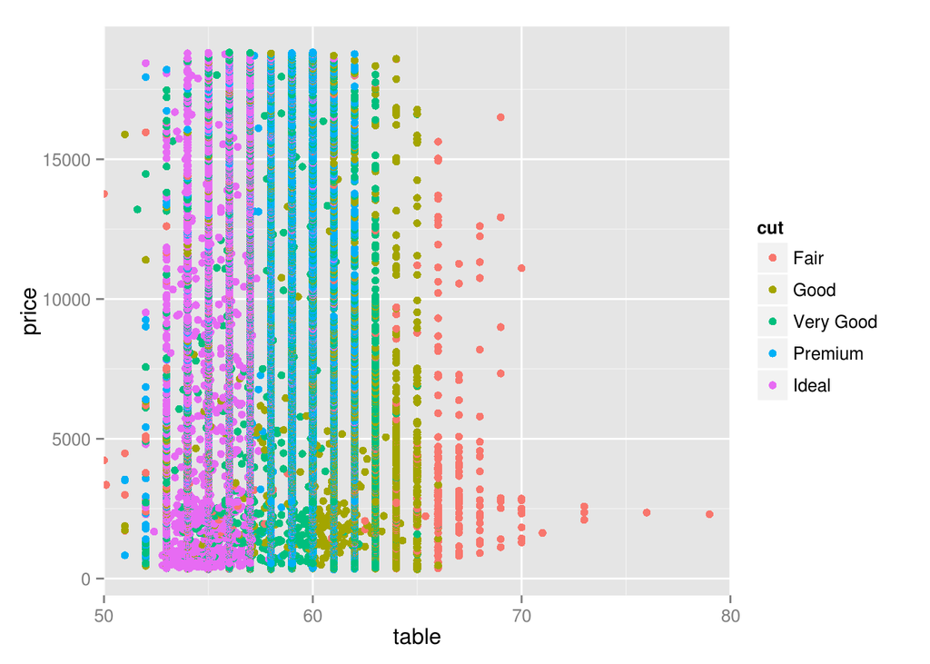

```r
ggplot(aes(x = table, y = price), data = diamonds) +
  geom_point(aes(color = cut)) +
  coord_cartesian(xlim = c(50,80))
```

#### What is the typical table range for the majority of diamonds of **ideal** cut?

53-57

### Price vs. Volume and Diamond Clarity

Create a scatterplot of diamond price vs. volume (x * y * z) and color the points by the clarity of diamonds. Use scale on the y-axis to take the log10 of price. You should also omit the top 1% of diamond volumes from the plot.  
Note: Volume is a very rough approximation of a diamond’s actual volume.

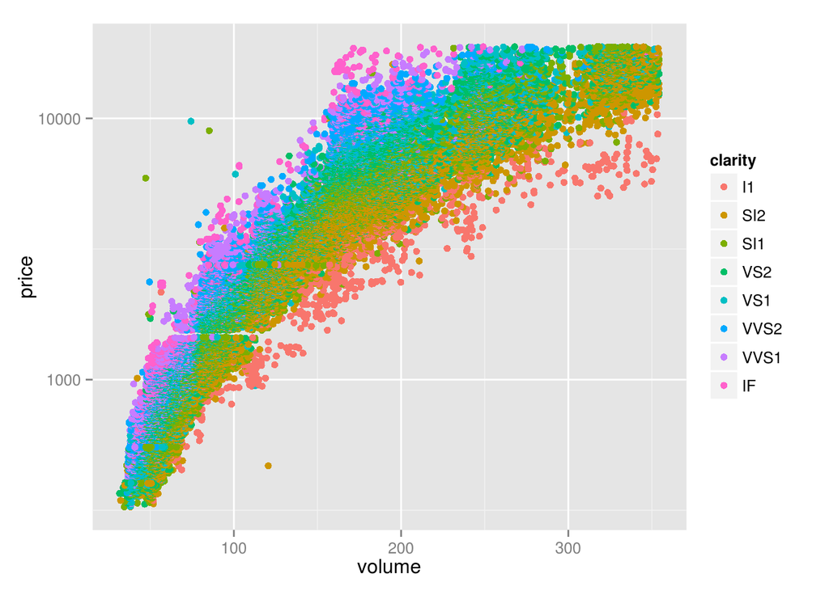

```r
diamonds$volume <- diamonds$x * diamonds$y * diamonds$z
ggplot(aes(x = volume, y = price), data = subset(diamonds, volume > 0 & volume < quantile(diamonds$volume, .99))) +
  geom_point(aes(color = clarity)) +
  scale_y_log10()
```

### Proportion of Friendships Initiated

#### Load Pseudo Facebook Friends Dataset

```r
pf <- read.csv('pseudo_facebook.tsv', sep = '\t')
```

#### Add new var, proportion of friendships initiated

```r
pf$prop_initiated <- pf$friendships_initiated / pf$friend_count
```

### prop_initiated vs. tenure

Create a line graph of the median proportion of friendships initiated (‘*prop_initiated*’) vs. *tenure* and color the line segment by *year_joined.bucket*.

From lesson 5, add var *year_joined* and *year_joined.bucket* to the dataset. The vars represent the year the user joined Facebook and the interval of years, respectively.

```r
pf$year_joined <- 2014 - ceiling(pf$tenure / 365)
table(pf$year_joined)
```

```
##
##  2005  2006  2007  2008  2009  2010  2011  2012  2013  2014
##     9    15   581  1507  4557  5448  9860 33366 43588    70
```

```r
pf$year_joined.bucket <- cut(pf$year_joined, breaks=c(2004,2009,2011,2012,2014))
table(pf$year_joined.bucket)
```

```
##
## (2004,2009] (2009,2011] (2011,2012] (2012,2014]
##        6669       15308       33366       43658
```

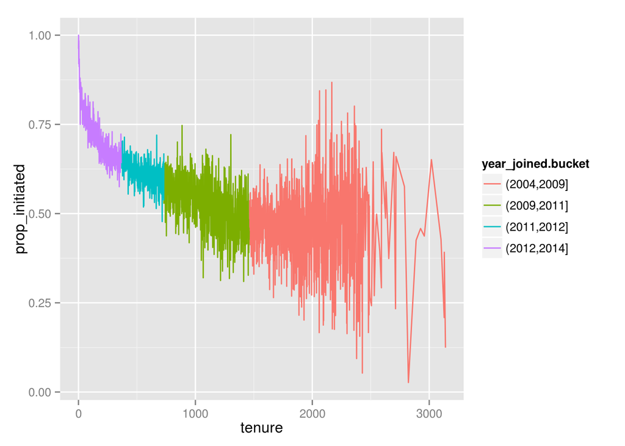

```r
ggplot(aes(x = tenure, y = prop_initiated), data = subset(pf, !is.na(prop_initiated))) +
  geom_line(stat = "summary", fun.y = median, aes(color = year_joined.bucket))
```

### Smoothing prop_initiated vs. tenure

You can use larger bins for tenure or add a smoother to the plot.

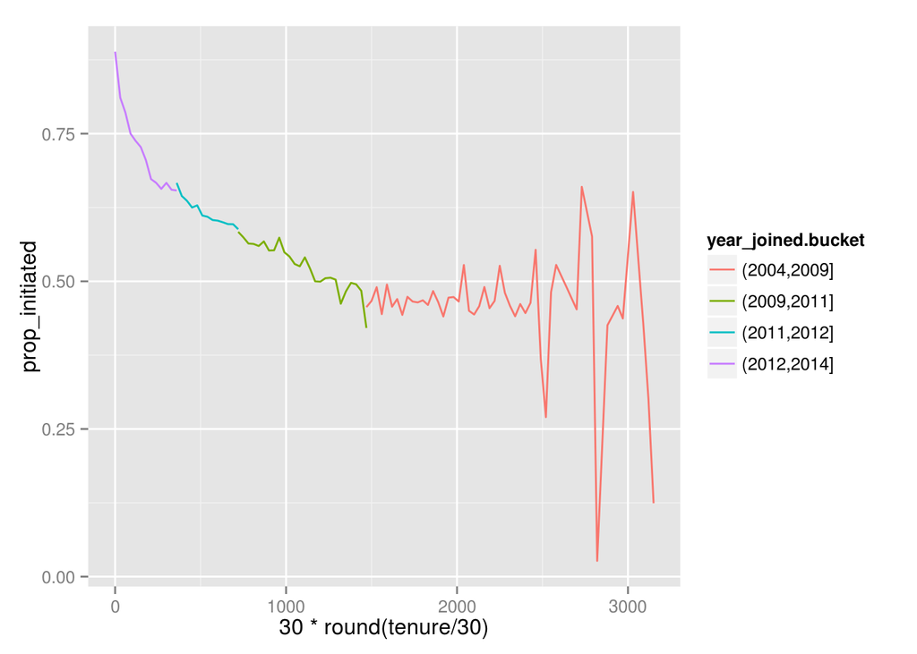

```r
## larger bins
ggplot(aes(x = 30 * round(tenure / 30), y = prop_initiated), data = subset(pf, !is.na(prop_initiated))) +
  geom_line(stat = "summary", fun.y = median, aes(color = year_joined.bucket))
```

```
## geom_smooth: method="auto" and size of largest group is >=1000, so using gam with formula: y ~ s(x, bs = "cs"). Use 'method = x' to change the smoothing method.
```

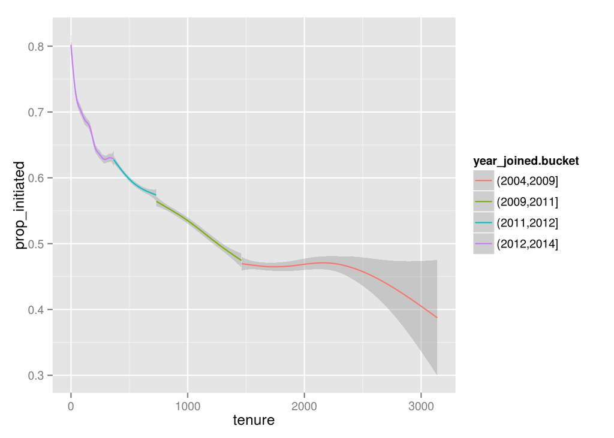

```r
## smoother
ggplot(aes(x = tenure, y = prop_initiated), data = subset(pf, !is.na(prop_initiated))) +
  geom_smooth(aes(color = year_joined.bucket))
```

#### Which group has the highest proportion of friendships initiated ?

Group [2012-2014]

#### For this group, what is the average(mean) proportion of friendships initiated?

0.67

```r
suppressMessages(library(dplyr))
pf %>%
  filter(!is.na(prop_initiated)) %>%
  group_by(year_joined.bucket) %>%
  summarise(mean = mean(prop_initiated))
```

```
## Source: local data frame [5 x 2]
##
##   year_joined.bucket      mean
## 1        (2004,2009] 0.4668151
## 2        (2009,2011] 0.5301298
## 3        (2011,2012] 0.5984577
## 4        (2012,2014] 0.6653892
## 5                 NA 0.6168644
```

#### Why do you think this happens?

I think users that have just joined Facebook are going to be more interested in looking for friends for several reasons:

1. Fewer friends, since they have have joined just recently.
2. People they already know, already on Facebook.
3. New users are more engaged

### Price/Carat Binned, Faceted, & Colored

Back to the diamonds dataset. Create a scatter plot of the price/carat ratio of diamonds. The variable x should be assigned to cut. The points should be colored by diamond color, and the plot should be faceted by clarity.

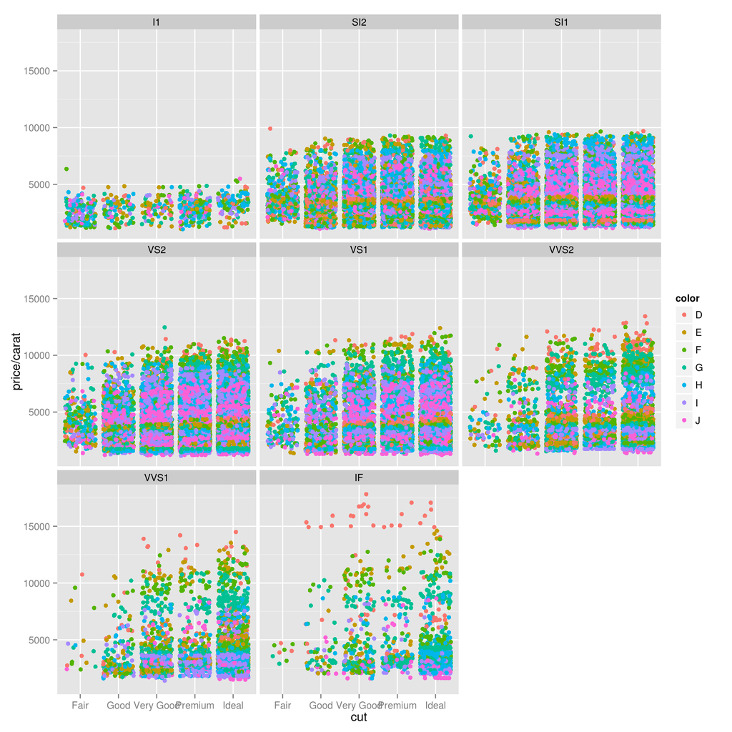

```r
ggplot(aes(x = cut, y = price/carat), data = diamonds) +
  geom_point(aes(color = color), position= position_jitter()) +
  facet_wrap(~clarity)
```

Sara Carvalho  
10-03-2015